# TalkingData_project1

Goncalo Oliveira

# 1 - Understand Context

Fraud risk is everywhere, but for companies that advertise on-line, click fraud can happen at an overwhelming volume, resulting in misleading click data and wasted money. Ad channels can drive up costs by simply clicking on the ad at a large scale.  
With over 1 billion smart mobile devices in active use every month, China is the largest mobile market in the world and therefore suffers from huge volumes of fraudulent traffic.

TalkingData, China’s largest independent big data service platform, covers over 70% of active mobile devices nationwide. They handle 3 billion clicks per day, of which 90% are potentially fraudulent. Their current approach to prevent click fraud for app developers is to measure the journey of a users click across their portfolio, and flag IP addresses who produce lots of clicks, but never end up installing apps. With this information, they’ve built an IP blacklist and device blacklist.

[Talking Data Kaggle website](https://www.kaggle.com/c/talkingdata-adtracking-fraud-detection)

**Objective**: predict whether a user will download an app after clicking a mobile app ad.

```r
# Imports
library(rmarkdown)
library(knitr)
library(ggrepel)
library(readr)
library(dplyr)
library(ggplot2)
library(lubridate)
library(tidyr)
library(caret)
```

# 2 - Collect Data

```r
df_original <- read_csv('data/train.csv')
paged_table(df_original, options = list(row.print = 5))
```

| ip | app | device | os | channel | click_time | attributed_time | is_attributed |
| --- | --- | --- | --- | --- | --- | --- | --- |
| 83230 | 3 | 1 | 13 | 379 | 2017-11-06 14:32:21 |  | 0 |
| 17357 | 3 | 1 | 19 | 379 | 2017-11-06 14:33:34 |  | 0 |
| 35810 | 3 | 1 | 13 | 379 | 2017-11-06 14:34:12 |  | 0 |
| 45745 | 14 | 1 | 13 | 478 | 2017-11-06 14:34:52 |  | 0 |
| 161007 | 3 | 1 | 13 | 379 | 2017-11-06 14:35:08 |  | 0 |
| 18787 | 3 | 1 | 16 | 379 | 2017-11-06 14:36:26 |  | 0 |
| 103022 | 3 | 1 | 23 | 379 | 2017-11-06 14:37:44 |  | 0 |
| 114221 | 3 | 1 | 19 | 379 | 2017-11-06 14:37:59 |  | 0 |
| 165970 | 3 | 1 | 13 | 379 | 2017-11-06 14:38:10 |  | 0 |
| 74544 | 64 | 1 | 22 | 459 | 2017-11-06 14:38:23 |  | 0 |

[output cut: 9990 more lines]

Data variables:

- **ip**: ip address of click;
- **app**: app id for marketing;
- **device**: device type id of user mobile phone (e.g., iphone 6 plus, iphone 7, huawei mate 7, etc.);
- **os**: os version id of user mobile phone;
- **channel**: channel id of mobile ad publisher;
- **click_time**: time-stamp of click (UTC);
- **attributed_time**: if user download the app for after clicking an ad, this is the time of the app download;
- **is_attributed**: the target that is to be predicted, indicating the app was downloaded.

**Obs:** Note that ip, app, device, os, and channel are encoded.

# 3 - Data Split and Under sampling

The variable *attributed_time* is perfectly correlated with the label we want to predict and is not available in new data.

```r
dim(df_original)
```

```
## [1] 184903890         8
```

There are 184903890 rows and 8 variables

The variable attributed time is perfectly correlated with the label we want to predict and is not available in new data. Also the variable to be predicted is a factor (categorical).

```r
df_drop <-
  df_original %>%
  select(-attributed_time) %>%
  mutate(is_attributed = as.factor(is_attributed))
```

Lets take a look on data range.

```r
range(df_drop$click_time)
```

```
## [1] "2017-11-06 14:32:21 UTC" "2017-11-09 16:00:00 UTC"
```

The train dataset is composed of 3 days that goes from 2017-11-06 14:32:21 to 2017-11-09 16:00:00.

Lets see if the label is balanced:

```r
table(df_drop$is_attributed)
```

```
##
##         0         1
## 184447044    456846
```

The train set is **not balanced**, lets under sample the train dataset considering the minor label

```r
train_index <- createDataPartition(df_drop$is_attributed,
                                   p = 0.7,
                                   list = FALSE,
                                   times = 1)

df_train <- df_drop[train_index,]
df_test_validation <- df_drop[-train_index,]

test_index = createDataPartition(df_test_validation$is_attributed,
                                 p = 0.67,
                                 list = FALSE,
                                 times = 1)

df_test <- df_test_validation[test_index, ]
df_vali <- df_test_validation[-test_index,]
```

See if no rows were missed:

```r
dim(df_drop)[1] == dim(df_train)[1] + dim(df_vali)[1] + dim(df_test)[1]
```

```
## [1] TRUE
```

See if label proportions were respected

```r
table_name <- c('raw data', 'train data', 'validation data', 'test data')

count = 1
for (df in list(df_drop, df_train, df_vali, df_test)){
  print(table_name[count])
  print(round(prop.table(table(df$is_attributed))*100, 3))
  count = count + 1
}
```

```
## [1] "raw data"
##
##      0      1
## 99.753  0.247
## [1] "train data"
##
##      0      1
## 99.753  0.247
## [1] "validation data"
##
##      0      1
## 99.753  0.247
## [1] "test data"
##
##      0      1
## 99.753  0.247
```

Balance output label in train dataset so that the model can learn the same as downloaded and not downloaded. An under sampling will be done due to the amount of data.

```r
train_1 <- df_train %>% filter(is_attributed == 1)
train_0 <- sample_n(df_train %>% filter(is_attributed == 0), nrow(train_1))
train <- bind_rows(train_1, train_0) %>% arrange(click_time)

# Verify if no row were lost
dim(train_1)[1] * 2 == dim(train)[1]
```

```
## [1] TRUE
```

# 4 - Explore the data

```r
# Check for NA values
train %>%
  summarise_all(~sum(is.na(.)))
```

```
## # A tibble: 1 x 7
##      ip   app device    os channel click_time is_attributed
##   <int> <int>  <int> <int>   <int>      <int>         <int>
## 1     0     0      0     0       0          0             0
```

```r
# Check distinct values
train %>%
  summarise_all(n_distinct)# A lot of distinct values occur per variable
```

```
## # A tibble: 1 x 7
##       ip   app device    os channel click_time is_attributed
##    <int> <int>  <int> <int>   <int>      <int>         <int>
## 1 197006   310   1629   174     177     214500             2
```

No NA values are present in the train dataset and a lot of distinct values occur per variable

We will now get the *hour* and the *day* from the *click_time* variable.

```r
train <- train %>%
  mutate(day = day(click_time),
         hour = hour(click_time)) %>%
  relocate(is_attributed, .after = last_col()) %>%
  arrange(click_time)

kable(head(train))
```

| ip | app | device | os | channel | click_time | day | hour | is_attributed |
| --- | --- | --- | --- | --- | --- | --- | --- | --- |
| 204158 | 35 | 1 | 13 | 21 | 2017-11-06 15:41:07 | 6 | 15 | 1 |
| 4951 | 3 | 1 | 19 | 137 | 2017-11-06 16:00:01 | 6 | 16 | 0 |
| 64516 | 35 | 1 | 13 | 21 | 2017-11-06 16:00:02 | 6 | 16 | 1 |
| 179413 | 10 | 1 | 13 | 113 | 2017-11-06 16:00:02 | 6 | 16 | 0 |
| 58637 | 12 | 1 | 13 | 178 | 2017-11-06 16:00:02 | 6 | 16 | 0 |
| 1256 | 3 | 1 | 13 | 115 | 2017-11-06 16:00:03 | 6 | 16 | 0 |

## 4.1 Data plot

Prepare data for plotting grouping by hour and day

```r
click_timeseries <- train %>%
  mutate(hour_trunc = floor_date(click_time, unit = 'hour')) %>%
  group_by(hour_trunc) %>%
  summarise(count_clicks = n(),
            downloads = sum(is_attributed==1),
            not_downloads = sum(is_attributed==0),
            perc_downloads = downloads / count_clicks *100) %>%
  filter(count_clicks > 100)
```

Function to plot number of downloads and non downloads through time

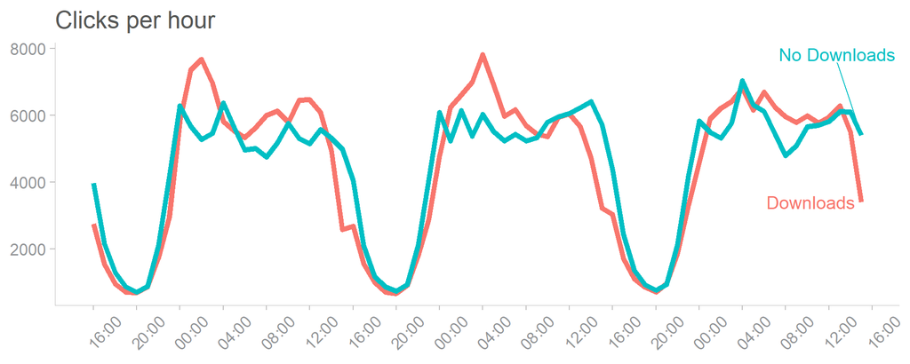

```r
downlods_per_hour <- function(df){
  ggplot(df) +
  geom_line(aes(x = hour_trunc, y = downloads, color = 'Downloads'), size = 2) +
  geom_line(aes(x = hour_trunc, y = not_downloads, color = 'No Downloads'), size = 2) +
  scale_x_datetime(date_breaks = '4 hours', date_labels = '%H:%M') +
  labs(title = 'Clicks per hour') +
  # Plot label at the end of line
  geom_text_repel(data = click_timeseries %>% filter(hour_trunc == max(hour_trunc)),
                  aes(x = hour_trunc , y = downloads,
                      color = 'Downloads', label = 'Downloads' ),
                  size = 5,nudge_y = 0) +
  geom_text_repel(data = click_timeseries %>% filter(hour_trunc == max(hour_trunc)),
                  aes(x = hour_trunc , y = not_downloads,
                      color = 'No Downloads', label = 'No Downloads' ),
                  size = 5, nudge_y = 2500, ) +
  # Removes legend
  theme_classic(base_size = 16) +
  theme(legend.position = "none",
        axis.title.x = element_blank(),
        axis.title.y = element_blank(),
        axis.line = element_line(size = .1, color = "#BFBEBE"),
        axis.text = element_text(color = "#929497"),
        axis.ticks.x = element_line(size = 0.5, color = "#BFBEBE"),
        axis.ticks.y = element_line(size = 0.5, color = "#BFBEBE"),
        plot.title = element_text(color = "#555655"),
        axis.text.x = element_text(vjust = 0.1, hjust = 0, angle = 45))
}
downlods_per_hour(click_timeseries)
```

It can be seen that the number of clicks has a pattern related to the hour. There is a high plateu between 00:00 and 13:00 and a low access between 14:00 and 22:00 h.

Lets see the percentage of downloads per hour

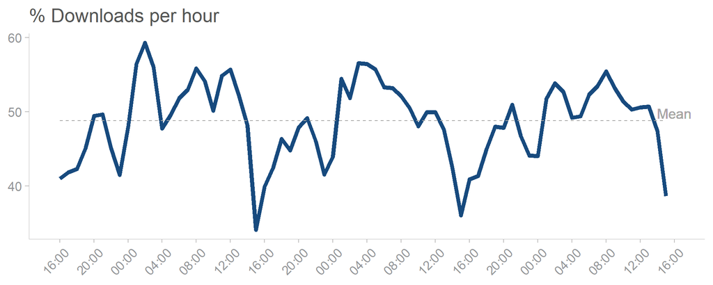

```r
perc_downloads_hour <- function(df){
  ggplot(df) +
  geom_line(aes(x = hour_trunc, y = perc_downloads), size = 2, color = "#174A7E") +
  geom_line(aes(x = hour_trunc, y = mean(perc_downloads)),
            linetype = 'dashed',
            color = "#A6A6A5") +
  geom_text(aes(x = max(hour_trunc) + hm('1 0'),
                y = mean(perc_downloads),
                label = 'Mean'),
            nudge_y = 1, size = 5, color = "#A6A6A5") +
  scale_x_datetime(date_breaks = '4 hours', date_labels = '%H:%M') +
  theme_classic(base_size = 16) +
  theme(legend.position = "none",
        axis.title.x = element_blank(),
        axis.title.y = element_blank(),
        axis.line = element_line(size = .1, color = "#BFBEBE"),
        axis.text = element_text(color = "#929497"),
        axis.ticks.x = element_line(size = 0.5, color = "#BFBEBE"),
        axis.ticks.y = element_line(size = 0.5, color = "#BFBEBE"),
        plot.title = element_text(color = "#555655"),
        axis.text.x = element_text(vjust = 0.8, hjust = 0.8, angle = 45)) +
  labs(title = '% Downloads per hour')
}
perc_downloads_hour(click_timeseries)
```

Lets evaluate if some of the variable may have an impact on final prediction.

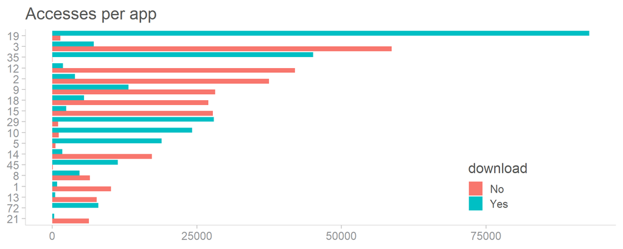

```r
plot_app <- function(){
  df_top_variable <- train %>%
    group_by(is_attributed, app) %>%
    summarise(count_app = n()) %>%
    arrange(desc(count_app))

  top_variable <- unique(df_top_variable$app[1:20])

  df_top_variable %>% filter(app %in% top_variable) %>%
    mutate(is_attributed = recode(is_attributed,
                                  '0' = 'No', '1' = 'Yes'))%>%
    ggplot() +
    geom_col(aes(x = reorder(app, count_app),
                 y = count_app,
                 fill = is_attributed),
             position = 'dodge') +
    theme_classic(base_size = 16)+
    theme(legend.position = c(0.8, 0.2),
          axis.title.x = element_blank(),
          axis.title.y = element_blank(),
          axis.line = element_line(size = .1, color = "#BFBEBE"),
          axis.text = element_text(color = "#929497"),
          axis.ticks.x = element_line(size = 0.5, color = "#BFBEBE"),
          axis.ticks.y = element_line(size = 0.5, color = "#BFBEBE"),
          plot.title = element_text(color = "#555655"),
          legend.text = element_text(colour = "#555655"),
          legend.title = element_text(colour = "#555655")) +
    labs(title = 'Accesses per app') +
    scale_fill_discrete(name = "download") +
    coord_flip()
}

plot_app()
```

It can be seen that the app has a considerable impact in predicting if a download will occur. For example. More than 90% accesses for app #19 downloaded. On the other side, accesses for app 3, 12, 14 commonly don’t download

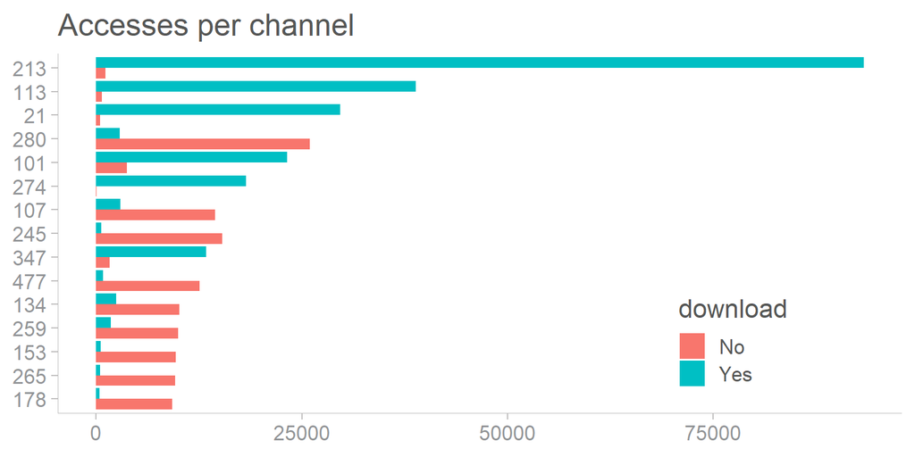

```r
plot_channel <- function(){
  df_top_variable <- train%>%
    group_by(is_attributed, channel) %>%
    summarise(count_channel = n()) %>%
    arrange(desc(count_channel))

  top_variable <- unique(df_top_variable$channel[1:15])

  df_top_variable %>% filter(channel %in% top_variable) %>%
    mutate(is_attributed = recode(is_attributed,
                                  '0' = 'No', '1' = 'Yes'))%>%
    ggplot() +
    geom_col(aes(x = reorder(channel, count_channel),
                 y = count_channel,
                 fill = is_attributed),
             position = 'dodge') +
    theme_classic(base_size = 16)+
    theme(legend.position = c(0.8, 0.2),
          axis.title.x = element_blank(),
          axis.title.y = element_blank(),
          axis.line = element_line(size = .1, color = "#BFBEBE"),
          axis.text = element_text(color = "#929497"),
          axis.ticks.x = element_line(size = 0.5, color = "#BFBEBE"),
          axis.ticks.y = element_line(size = 0.5, color = "#BFBEBE"),
          plot.title = element_text(color = "#555655"),
          legend.text = element_text(colour = "#555655"),
          legend.title = element_text(colour = "#555655")) +
    labs(title = 'Accesses per channel') +
    scale_fill_discrete(name = "download") +
    coord_flip()
}
plot_channel()
```

The channel seems to have a big impact on download rate, for instace if the the user accesses from channel 213, 113 and 21 it will probably download. On the other hand, channels 280, 245, 107 477 gave a low probability of download.

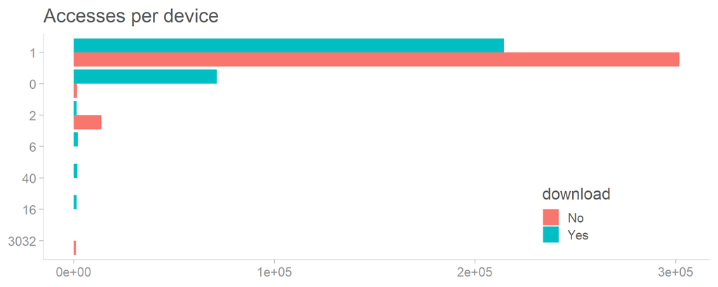

```r
plot_device <- function(){
  df_top_variable <- train %>%
    group_by(is_attributed, device) %>%
    summarise(count_device = n()) %>%
    arrange(desc(count_device))

  top_variable <- unique(df_top_variable$device[1:10])

  df_top_variable %>% filter(device %in% top_variable) %>%
    mutate(is_attributed = recode(is_attributed,
                                  '0' = 'No', '1' = 'Yes'))%>%
    ggplot() +
    geom_col(aes(x = reorder(device, count_device),
                 y = count_device,
                 fill = is_attributed),
             position = 'dodge') +
    theme_classic(base_size = 16)+
    theme(legend.position = c(0.8, 0.2),
          axis.title.x = element_blank(),
          axis.title.y = element_blank(),
          axis.line = element_line(size = .1, color = "#BFBEBE"),
          axis.text = element_text(color = "#929497"),
          axis.ticks.x = element_line(size = 0.5, color = "#BFBEBE"),
          axis.ticks.y = element_line(size = 0.5, color = "#BFBEBE"),
          plot.title = element_text(color = "#555655"),
          legend.text = element_text(colour = "#555655"),
          legend.title = element_text(colour = "#555655")) +
    labs(title = 'Accesses per device') +
    scale_fill_discrete(name = "download") +
    coord_flip()
}

plot_device()
```

It can be seen that device 1 has the majority of the accesses, however there is a considerable number of downloads from device 0.

# 5 - Feature Engineering

```r
feature_eng <- function(df, with_label = TRUE){
  df_eng <-
  df %>%
  # Grouping by ip in each hour of the day
  add_count(ip, day, hour) %>%  rename('ip_day_hour' = n) %>%
  add_count(ip, day, hour, channel) %>% rename('ip_day_hour_channel' = n) %>%
  add_count(ip, day, hour, app) %>% rename('ip_day_hour_app' = n) %>%
  add_count(ip, day, hour, app, channel) %>% rename('ip_day_hour_app_channel' = n) %>%
  # Grouping by ip in each day
  add_count(ip, day) %>%  rename('ip_day' = n) %>%
  add_count(ip, day, channel) %>% rename('ip_day_channel' = n) %>%
  add_count(ip, day, app) %>% rename('ip_day_app' = n) %>%
  add_count(ip, day, app, channel) %>% rename('ip_day_app_channel' = n) %>%
  # Grouping by ip, device and os in each hour of the day
  add_count(ip, device, os, day, hour ) %>% rename('ip_device_os_hour_day' = n) %>%
  add_count(ip, device, os, day, hour, channel) %>% rename('ip_device_os_day_hour_channel' = n) %>%
  add_count(ip, device, os, day, hour, app) %>% rename('ip_device_os_day_hour_app' = n) %>%
  add_count(ip, device, os, day, hour, app, channel) %>% rename('ip_device_os_day_hour_app_channel' = n) %>%
  # Grouping by ip, device and os in each day
  add_count(ip, device, os, day) %>% rename('ip_device_os_day' = n) %>%
  add_count(ip, device, os, day, channel) %>% rename('ip_device_os_day_channel' = n) %>%
  add_count(ip, device, os, day, app) %>% rename('ip_device_os_day_app' = n) %>%
  add_count(ip, device, os, day, app, channel) %>% rename('ip_device_os_day_app_channel' = n)

  df_eng <- df_eng %>% select(-c(ip, click_time, day))

  return(df_eng)
}

train_fe <- feature_eng(train)
paged_table(train_fe)
```

| app | device | os | channel | hour | is_attributed | ip_day_hour | ip_day_hour_channel | ip_day_hour_app | ip_day_hour_app_channel | ip_day | ip_day_channel | ip_day_app | ip_day_app_channel | ip_device_os_hour_day | ip_device_os_day_hour_channel | ip_device_os_day_hour_app | ip_device_os_day_hour_app_channel | ip_device_os_day | ip_device_os_day_channel | ip_device_os_day_app | ip_device_os_day_app_channel |
| --- | --- | --- | --- | --- | --- | --- | --- | --- | --- | --- | --- | --- | --- | --- | --- | --- | --- | --- | --- | --- | --- |
| 35 | 1 | 13 | 21 | 15 | 1 | 1 | 1 | 1 | 1 | 1 | 1 | 1 | 1 | 1 | 1 | 1 | 1 | 1 | 1 | 1 | 1 |
| 3 | 1 | 19 | 137 | 16 | 0 | 1 | 1 | 1 | 1 | 1 | 1 | 1 | 1 | 1 | 1 | 1 | 1 | 1 | 1 | 1 | 1 |
| 35 | 1 | 13 | 21 | 16 | 1 | 3 | 2 | 2 | 2 | 3 | 2 | 2 | 2 | 2 | 1 | 1 | 1 | 2 | 1 | 1 | 1 |
| 10 | 1 | 13 | 113 | 16 | 0 | 1 | 1 | 1 | 1 | 1 | 1 | 1 | 1 | 1 | 1 | 1 | 1 | 1 | 1 | 1 | 1 |
| 12 | 1 | 13 | 178 | 16 | 0 | 5 | 1 | 2 | 1 | 8 | 1 | 2 | 1 | 3 | 1 | 2 | 1 | 4 | 1 | 2 | 1 |
| 3 | 1 | 13 | 115 | 16 | 0 | 2 | 1 | 1 | 1 | 3 | 1 | 1 | 1 | 1 | 1 | 1 | 1 | 2 | 1 | 1 | 1 |
| 35 | 1 | 13 | 274 | 16 | 1 | 1 | 1 | 1 | 1 | 1 | 1 | 1 | 1 | 1 | 1 | 1 | 1 | 1 | 1 | 1 | 1 |
| 19 | 0 | 24 | 210 | 16 | 1 | 1 | 1 | 1 | 1 | 2 | 1 | 1 | 1 | 1 | 1 | 1 | 1 | 1 | 1 | 1 | 1 |
| 14 | 1 | 19 | 401 | 16 | 0 | 1 | 1 | 1 | 1 | 2 | 1 | 1 | 1 | 1 | 1 | 1 | 1 | 1 | 1 | 1 | 1 |
| 1 | 1 | 9 | 134 | 16 | 0 | 1 | 1 | 1 | 1 | 2 | 1 | 1 | 1 | 1 | 1 | 1 | 1 | 1 | 1 | 1 | 1 |

[output cut: 9990 more lines]

# 6 - Feature Engineering on test and validation dataset

Feature Engineering on test and validation dataset

```r
# Add day and hour variables
test <- test %>%
    mutate(day = day(click_time),
           hour = hour(click_time)) %>%
    relocate(is_attributed, .after = last_col())

vali <- vali %>%
  mutate(day = day(click_time),
          hour = hour(click_time)) %>%
  relocate(is_attributed, .after = last_col())

# Feature Engineering
test_fe <- feature_eng(test)
vali_fe <- feature_eng(vali)
```

# 7 - Model Selection

We will run a set of classification models mainly with default settings in order to compare the performance of each one. The following models will be tested:

- Random Forest
- Naive-Bayes
- XGBoost
- LightGBM

In order to evaluate the performance the following metrics will be measured:

- Accuracy
- Precision
- Recall
- F1
- AUC (Area under the curve)

A greater importance will be given to the AUC because it is the metric that will be used to score the competition.

```r
# We will try the following models
library(parallel)
library(doParallel)

# Models
library(randomForest) # Random Forest
library(e1071) # Naive Bayes
library(xgboost) # XGBoost
library(lightgbm) #LGBM

# Metrics
library(pROC)
library(ROCR)
```

## Built function to score the models

```r
model_score <- function(pred, label){

  factor_pred <- as.factor(ifelse(pred > 0.5,1,0))
  cm <- caret::confusionMatrix(factor_pred, label)

  auc_score <- auc(label, pred)

  score <- round(c(cm$overall['Accuracy'],
                   cm$byClass[c('Precision', 'Recall', 'F1')],
                   auc_score), 2)
  return(score)
}
```

## Random Forest

```r
rf <- randomForest(is_attributed ~.,
                   data = train_fe,
                   ntree = 25,
                   nodesize = 100, # nodesize to avoid overfitting
                   importance = TRUE)

saveRDS(rf, "models/rf.rds")
```

### RF Score

The test model will be scored with the test data as the train score was good

```r
rf_predicted <- predict(rf, test_fe, type = 'prob')
rf_prob <- rf_predicted[,2]

RF_score <- model_score(rf_prob, test_fe$is_attributed)
rm(rf_prob)
```

## Naive Bayes

```r
nb <- naiveBayes(is_attributed ~.,
                 data = train_fe,
                 laplace = 1)

saveRDS(nb, "models/nb.rds")
```

### NB Score

The NB train score model presented a poor value, probably due to the underfitting and the lack of the model to predict the non linear relation

```r
nb_train_pred <- predict(nb, train_fe, 'raw')
nb_pred_prob <- nb_train_pred[,2]

NB_score <- model_score(nb_pred_prob, train_fe$is_attributed)
```

## Logistic Regression

```r
prepocValues <- preProcess(train_fe, method = c('center', 'scale'))

train_scaled <- predict(prepocValues, train_fe)

logReg <- glm(is_attributed ~.,
              data = train_scaled,
              family=binomial(link='logit'))

saveRDS(logReg, "models/logreg.rds")
```

### Logistic Regression Score

The score will be performed on train since it is below the achieved with the other models

```r
logReg_predict <- predict(logReg, train_scaled, type = 'response')

logReg_score <- model_score(logReg_predict, train_scaled$is_attributed)
```

## XGBoost

```r
dtrain <- xgb.DMatrix(data = as.matrix(train_fe %>% select(-is_attributed)),
                      label= as.matrix(train_fe$is_attributed))

xgb_model <- xgboost(data = dtrain,
                     objective = "binary:logistic",
                     eval_metric = 'auc',
                     verbose = 0,
                     nrounds = 50)

saveRDS(xgb_model, "models/xgboost.rds")
```

### XGBoost Score

```r
pred <- predict(xgb_model, as.matrix(test_fe %>% select(-is_attributed)), type = 'response')

xgb_score <- model_score(pred, test_fe$is_attributed)
```

## Light GBM

```r
d2train <- lgb.Dataset(data = as.matrix(train_fe %>% select(-is_attributed)),
                      label= as.matrix(train_fe$is_attributed))

# Model parameters
params = list(objective = "binary",
              metric = 'auc',
              force_row_wise = T)

# Train Model
light <- lightgbm(data = d2train,
                  params = params,
                  verbose = 0)

saveRDS(light, "models/light.rds")
```

### LightGBM Score

```r
pred_light <- predict(light, as.matrix(test_fe %>% select(-is_attributed)))

light_score <- model_score(pred_light, test_fe$is_attributed)
```

# Base models comparison

Final table comparing models score

```r
models_score_geral <- data.frame('RandomForest' = RF_score,
                    'NaiveBayes' = NB_score,
                    'LogisticRegression' = logReg_score,
                    'XGBoost' = xgb_score,
                    'LightGBM' = light_score,
                    row.names = c('Accuracy', 'Precision', 'Recall', 'F1', 'AUC'))

paged_table(models_score_geral)
```

|  | RandomForest | NaiveBayes | LogisticRegression | XGBoost | LightGBM |
| --- | --- | --- | --- | --- | --- |
| Accuracy | 0.94 | 0.55 | 0.75 | 0.96 | 0.96 |
| Precision | 1.00 | 0.53 | 0.73 | 1.00 | 1.00 |
| Recall | 0.94 | 0.96 | 0.79 | 0.96 | 0.96 |
| F1 | 0.97 | 0.68 | 0.76 | 0.98 | 0.98 |
| AUC | 0.93 | 0.72 | 0.82 | 0.96 | 0.96 |

The LightGBM is not only one of the fastest but also presents the best results it will be considered for tuning purposes and feature selection.

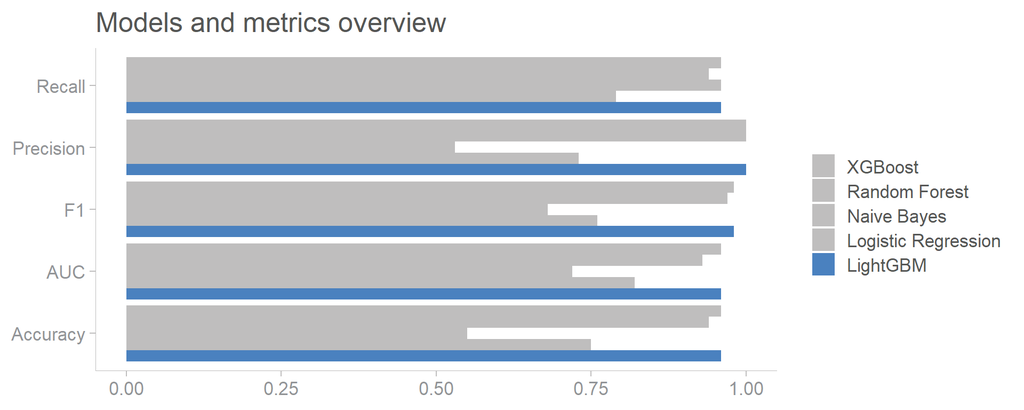

```r
# Plot graphic comparic metrics and models
table_score <- as_tibble(models_score_geral)

GRAY9 <- "#BFBEBE"
BLUE2 <- "#4A81BF"

table_score %>%
  mutate(metric = row.names(models_score_geral)) %>%
  relocate(metric, .before = everything()) %>%
  gather('RandomForest', 'NaiveBayes', 'LogisticRegression', 'XGBoost', 'LightGBM', key = 'model',value = 'score') %>%
  arrange(metric) %>%
  ggplot(aes(x = metric, y = score, fill = model)) +
  geom_bar(stat = 'identity', position = 'dodge') +
  theme_classic(base_size = 16)+
  theme(axis.title.x = element_blank(),
        axis.title.y = element_blank(),
        axis.line = element_line(size = .1, color = "#BFBEBE"),
        axis.text = element_text(color = "#929497"),
        axis.ticks.x = element_line(size = 0.5, color = "#BFBEBE"),
        axis.ticks.y = element_line(size = 0.5, color = "#BFBEBE"),
        plot.title = element_text(color = "#555655"),
        legend.text = element_text(colour = "#555655"),
        legend.title = element_blank()) +
  scale_fill_manual(values = c(BLUE2, GRAY9,GRAY9,GRAY9,GRAY9),
                    labels = c("LightGBM",
                               "Logistic Regression",
                               "Naive Bayes",
                               "Random Forest",
                               "XGBoost"),
                    guide = guide_legend(reverse = T)) +
  coord_flip() +
  labs(title = "Models and metrics overview" )
```

# Feature Selection

We will search for the most impact features, while avoiding to decrease the train score. The approach will improve the generalization of the model for the new data. Latelly it will the generalization will also be improve on hyper parameter tuning.

```r
tree_imp <- lgb.importance(light, percentage = TRUE)
tree_imp[,2:4] <- round(tree_imp[,2:4], 3)
df_tree_imp <- as_tibble(tree_imp)
paged_table(df_tree_imp)
```

| Feature | Gain | Cover | Frequency |
| --- | --- | --- | --- |
| app | 0.655 | 0.326 | 0.332 |
| channel | 0.241 | 0.156 | 0.220 |
| ip_day | 0.062 | 0.127 | 0.102 |
| os | 0.019 | 0.181 | 0.162 |
| hour | 0.006 | 0.064 | 0.053 |
| device | 0.006 | 0.062 | 0.039 |
| ip_day_app | 0.003 | 0.009 | 0.024 |
| ip_device_os_day | 0.002 | 0.005 | 0.020 |
| ip_device_os_hour_day | 0.001 | 0.006 | 0.009 |
| ip_day_hour_channel | 0.001 | 0.022 | 0.009 |

[output cut: 10 more lines]

- app
- channel
- ip_day
- os
- hour
- device

```r
d3train <- lgb.Dataset(data = as.matrix(train_fe %>% select(app, channel, ip_day, os, hour, device)),
                      label= as.matrix(train_fe$is_attributed))

# Model parameters
params2 = list(objective = "binary",
              metric = 'auc',
              force_row_wise = T)

# Train Model
light2 <- lightgbm(data = d3train,
                  params = params2,
                  verbose = 0)
```

```r
pred_light <- predict(light2, as.matrix(test_fe %>% select(app, channel, ip_day, os, hour, device)))

light_score2 <- model_score(pred_light, test_fe$is_attributed)
print(light_score)
```

```
##  Accuracy Precision    Recall        F1
##      0.96      1.00      0.96      0.98      0.96
```

# Hyper Parameter Tuning

We will look for several combinations of hyper parameters. The main objective is to improve the validation prediction score considering the AUC metric. There are 336 different combinations.

```r
lightGBM_grid <- expand.grid( max_bin = c(255, 500, 1000, 1500),#255
                              learning_rate = c(0.01, 0.05, 0.1 ), #0.1
                              num_iterations = c(100, 250, 500, 1000), #100
                              num_leaves = c(6, 8, 13, 18, 25, 31, 50)) #31
```

The models will be trained with different parameters and the AUC score of each one kept on a score_list variable.

```r
cluster <- makeCluster(detectCores() - 1)
registerDoParallel(cluster)

score_list = c()
for (row in 1:nrow(lightGBM_grid)){

  print(paste(as.character(row), '/',  as.character(nrow(lightGBM_grid))))

  n  = lightGBM_grid[row,]

  params = list(objective = "binary",
                metric = 'auc',
                force_row_wise = T,
                num_threads = 11,
                learning_rate = n$learning_rate,
                num_iterations = n$num_iterations,
                num_leaves = n$num_leaves,
                max_bin = n$max_bin)

  d4train <- lgb.Dataset(data = as.matrix(train_fe %>% select(app, channel, ip_day, os, hour, device)),
                         label= as.matrix(train_fe$is_attributed))

  light_hyper <- lightgbm(data = d4train,
                    params = params,
                    verbose = 0)

  vali_light <- predict(light_hyper, as.matrix(vali_fe %>% select(app, channel, ip_day, os, hour, device)))

  auc_score <- auc(vali_fe$is_attributed, vali_light, quiet = TRUE)
  print(auc_score)
  score_list <- c(score_list, auc_score)
}

grid_score <- lightGBM_grid %>% mutate(auc = score_list)
grid_score %>% arrange(desc(auc)) %>% head()

write_csv(grid_score, file = 'models/grid_score.csv')
```

| max_bin | learning_rate | num_iterations | num_leaves | auc |
| --- | --- | --- | --- | --- |
| 500 | 0.10 | 500 | 13 | 0.9655786 |
| 255 | 0.10 | 250 | 25 | 0.9654922 |
| 255 | 0.10 | 1000 | 8 | 0.9654878 |
| 500 | 0.10 | 250 | 31 | 0.9654868 |
| 1000 | 0.10 | 1000 | 8 | 0.9654820 |
| 1500 | 0.10 | 1000 | 8 | 0.9654820 |
| 1000 | 0.05 | 500 | 50 | 0.9654790 |
| 1500 | 0.05 | 500 | 50 | 0.9654790 |
| 500 | 0.10 | 1000 | 8 | 0.9654697 |
| 1500 | 0.10 | 500 | 18 | 0.9654279 |

[output cut: 326 more lines]

The model with the best validation score had the following parameters:

- **max_bin** = 500
- **learning_rate** = 0.1
- **num_iterations** = 500
- **num_leaves** = 13

# Train final model with all available data

```r
# Import data
df_train <- read_csv('data/train.csv')
df_train <- df_train %>% select(-attributed_time)
```

```r
feature_eng_simplified <- function(df, with_label = TRUE){
  df_eng <-
  df %>%
  # Grouping by ip in each day
  add_count(ip, day) %>%  rename('ip_day' = n)


  df_eng <- df_eng %>% select(-c(ip, click_time, day))

  return(df_eng)
}
```

Balance data, convert label to factor and perform feature engineering as before.

```r
train_1 <- df_train %>% filter(is_attributed == 1)
train_0 <- sample_n(df_train %>% filter(is_attributed == 0), nrow(train_1))
train <- bind_rows(train_1, train_0) %>% arrange(click_time)

rm(df_train)
rm(train_1)
rm(train_0)

train$is_attributed <- as.factor(train$is_attributed)

train <- train %>%
  mutate(day = day(click_time),
         hour = hour(click_time)) %>%
  relocate(is_attributed, .after = last_col())

train_fe <- feature_eng_simplified(train)
```

Train model with optimized hyper parameters.

```r
dtrain <- lgb.Dataset(data = as.matrix(train_fe %>% select(app, channel, ip_day, os, hour, device)),
                       label= as.matrix(train_fe$is_attributed))

params = list(objective = "binary",
             metric = 'auc',
             force_row_wise = T,
             num_threads = 11,
             learning_rate = 0.1,
             num_iterations = 500,
             num_leaves = 13,
             max_bin = 500)

light <- lightgbm(data = dtrain,
                  params = params,
                  verbose = 0)
```

Import the new dataset which has unknown label

```r
new_data <- read_csv(file = 'data/test.csv')

new_data <- new_data %>%
  mutate(day = day(click_time),
         hour = hour(click_time))

new_data_fe <- feature_eng_simplified(new_data)
```

Perform the simplified feature engineering.

```r
pred_final <- predict(light, as.matrix(new_data_fe %>% select(app, channel, ip_day, os, hour, device)))

df_pred_final <- data.frame(click_id = new_data$click_id,
                            is_attributed = pred_final)

write_csv(df_pred_final, file = 'data/results3.csv')
```

The predict label were submitted to the kaggle and a final score was achieved:

- **private score** = 0.95752
- **public score** = 0.95677

The final score is similar to the best validation which tell us that were able to build a model that predict with new data.